# R Notebook

```r
filename <- "auto-mpg.csv"
mydata <- read.csv(filename, header=TRUE, sep=",")
str(mydata)
```

```
## 'data.frame':    398 obs. of  9 variables:
##  $ mpg         : num  18 15 18 16 17 15 14 14 14 15 ...
##  $ cylinders   : int  8 8 8 8 8 8 8 8 8 8 ...
##  $ displacement: num  307 350 318 304 302 429 454 440 455 390 ...
##  $ horsepower  : Factor w/ 94 levels "?","100","102",..: 17 35 29 29 24 42 47 46 48 40 ...
##  $ weight      : int  3504 3693 3436 3433 3449 4341 4354 4312 4425 3850 ...
##  $ acceleration: num  12 11.5 11 12 10.5 10 9 8.5 10 8.5 ...
##  $ model.year  : int  70 70 70 70 70 70 70 70 70 70 ...
##  $ origin      : int  1 1 1 1 1 1 1 1 1 1 ...
##  $ car.name    : Factor w/ 305 levels "amc ambassador brougham",..: 50 37 232 15 162 142 55 224 242 2 ...
```

“The data concerns city-cycle fuel consumption in miles per gallon, to be predicted in terms of 3 multivalued discrete and 5 continuous attributes.” (Quinlan, 1993)

Attribute Information:

1. mpg: continuous
2. cylinders: multi-valued discrete
3. displacement: continuous
4. horsepower: continuous
5. weight: continuous
6. acceleration: continuous
7. model year: multi-valued discrete
8. origin: multi-valued discrete
9. car name: string (unique for each instance)
- After I fetch the auto mpg data from local folder, I looked structure of data. It is easy to see and understand of data by str() cmd in R. In first glance, it has some missing values in horsepower and some features needs to be converted from factor level to int or double like horsepower, also i will exclude car.name feature in my model!!!

```r
temp=as.character(mydata$horsepower)
mydata$horsepower=as.numeric(temp) # after conversion, all missing turns out to be `NA`!!
mydata=mydata[-9] # I EXCLUDED THE CAR NAME VARIABLE IN DATA SET
#mydata1=as.data.frame(scale(mydata, scale = T)) # ALSO NORMALIZED THE DATA
str(mydata)
```

```
## 'data.frame':    398 obs. of  8 variables:
##  $ mpg         : num  18 15 18 16 17 15 14 14 14 15 ...
##  $ cylinders   : int  8 8 8 8 8 8 8 8 8 8 ...
##  $ displacement: num  307 350 318 304 302 429 454 440 455 390 ...
##  $ horsepower  : num  130 165 150 150 140 198 220 215 225 190 ...
##  $ weight      : int  3504 3693 3436 3433 3449 4341 4354 4312 4425 3850 ...
##  $ acceleration: num  12 11.5 11 12 10.5 10 9 8.5 10 8.5 ...
##  $ model.year  : int  70 70 70 70 70 70 70 70 70 70 ...
##  $ origin      : int  1 1 1 1 1 1 1 1 1 1 ...
```

```r
set.seed(101)

sample <- sample.int(n = nrow(mydata), size = floor(.70*nrow(mydata)), replace = F)
train <- mydata[sample, ]
test  <- mydata[-sample, ]
```

After separation, I will replace missing ones with mean of horsepower in the training as i did below….

```r
missing.index=which(is.na(train$horsepower))
train$horsepower[missing.index]=mean(train$horsepower[-(missing.index)])
```

Let`s make some diagnostic on training data before modelling…

```r
summary(train)
```

```
##       mpg          cylinders      displacement     horsepower
##  Min.   : 9.00   Min.   :3.000   Min.   : 68.0   Min.   : 48
##  1st Qu.:17.00   1st Qu.:4.000   1st Qu.:105.0   1st Qu.: 78
##  Median :22.75   Median :4.000   Median :151.0   Median : 95
##  Mean   :23.36   Mean   :5.493   Mean   :195.1   Mean   :106
##  3rd Qu.:29.00   3rd Qu.:8.000   3rd Qu.:265.8   3rd Qu.:125
##  Max.   :46.60   Max.   :8.000   Max.   :455.0   Max.   :230
##      weight      acceleration    model.year        origin
##  Min.   :1613   Min.   : 8.0   Min.   :70.00   Min.   :1.000
##  1st Qu.:2230   1st Qu.:13.7   1st Qu.:73.00   1st Qu.:1.000
##  Median :2834   Median :15.5   Median :76.00   Median :1.000
##  Mean   :2984   Mean   :15.4   Mean   :75.94   Mean   :1.572
##  3rd Qu.:3627   3rd Qu.:17.0   3rd Qu.:79.00   3rd Qu.:2.000
##  Max.   :5140   Max.   :23.5   Max.   :82.00   Max.   :3.000
```

firstly, I might tell that displacement and horsepower have some skewness by comparing their own median with mean.This features might have bad effect on our least square modelling, is based on the predictors should have normally distributed. However, it can be too early to tell this. Now lets make some graphical summaries:

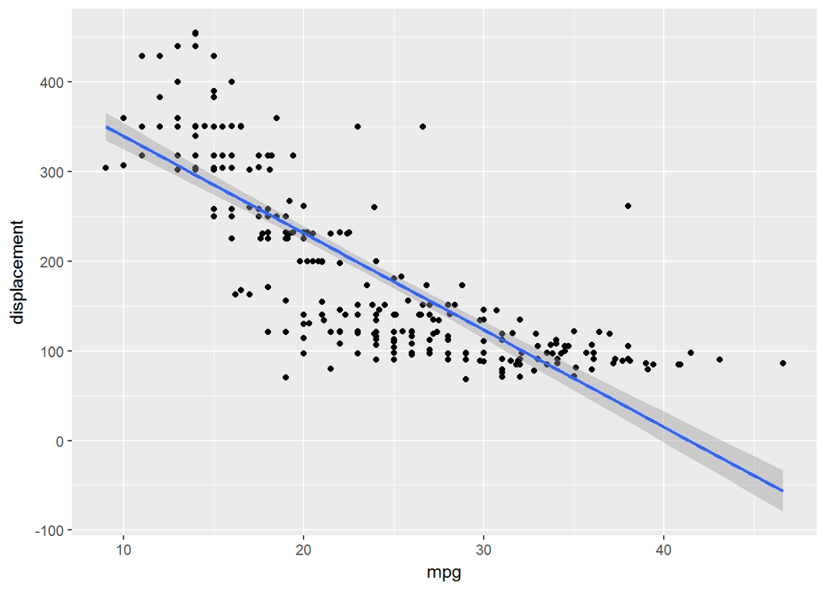

```r
require(ggplot2)
ggplot(train,aes(mpg,displacement))+geom_point()+stat_smooth(method = "lm")
```

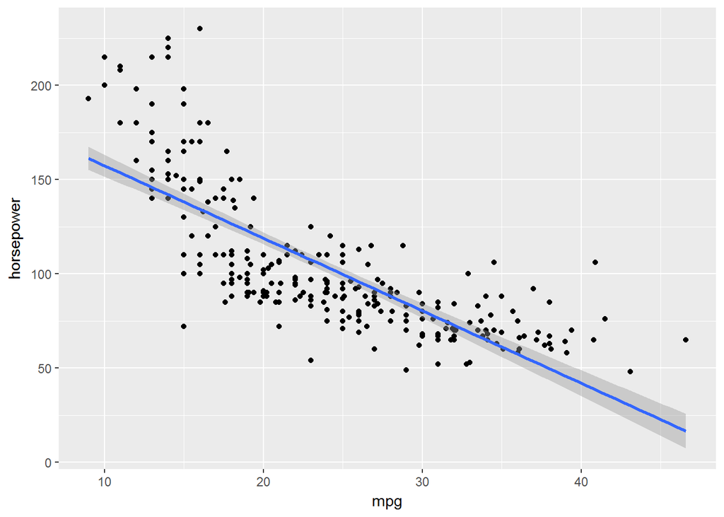

```r
ggplot(train,aes(mpg,horsepower))+geom_point()+stat_smooth(method = "lm")
```

As seen above graphs, both features might needs to get transformation because of skewness in these variable.Probably, 1/sqrt() transformation might be used !!!

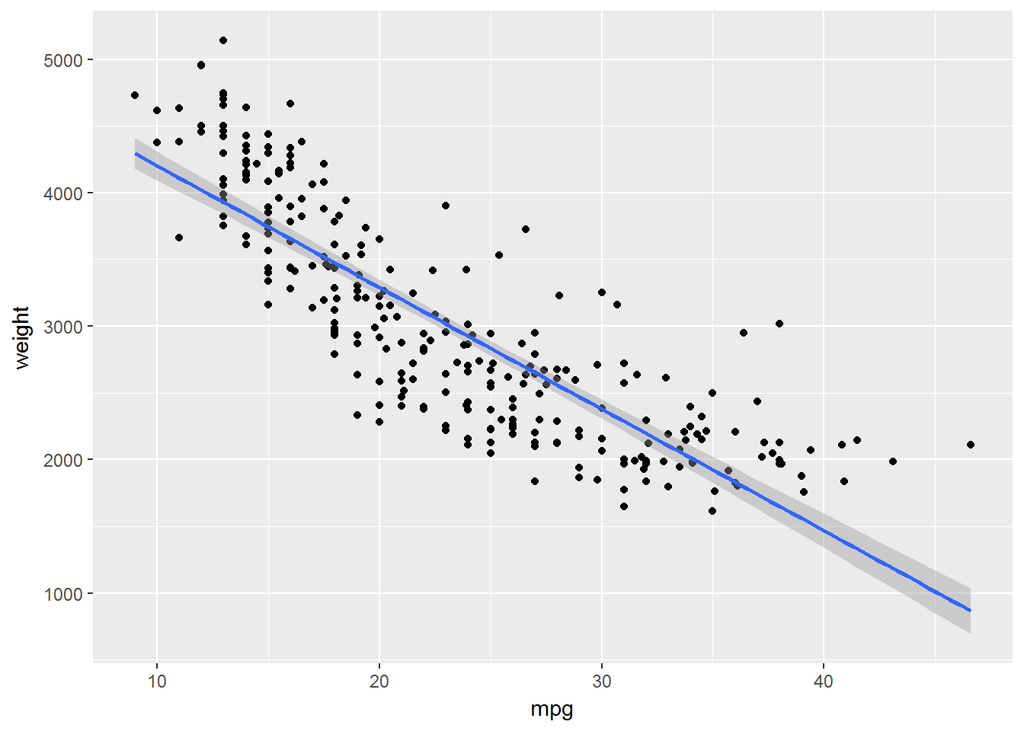

```r
ggplot(train,aes(mpg,weight))+geom_point()+stat_smooth(method = "lm")
```

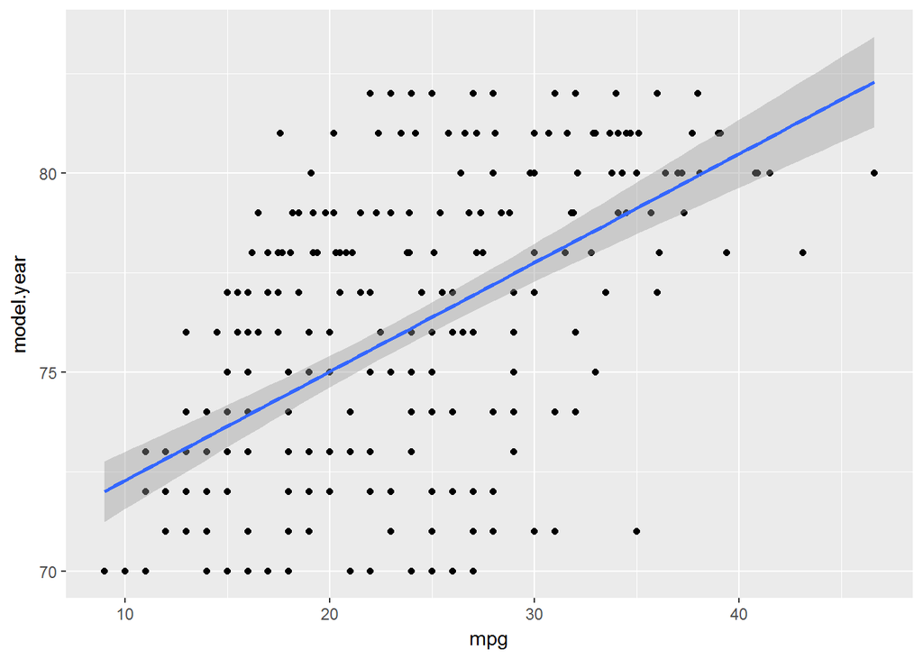

```r
ggplot(train,aes(mpg,model.year))+geom_point()+stat_smooth(method = "lm")
```

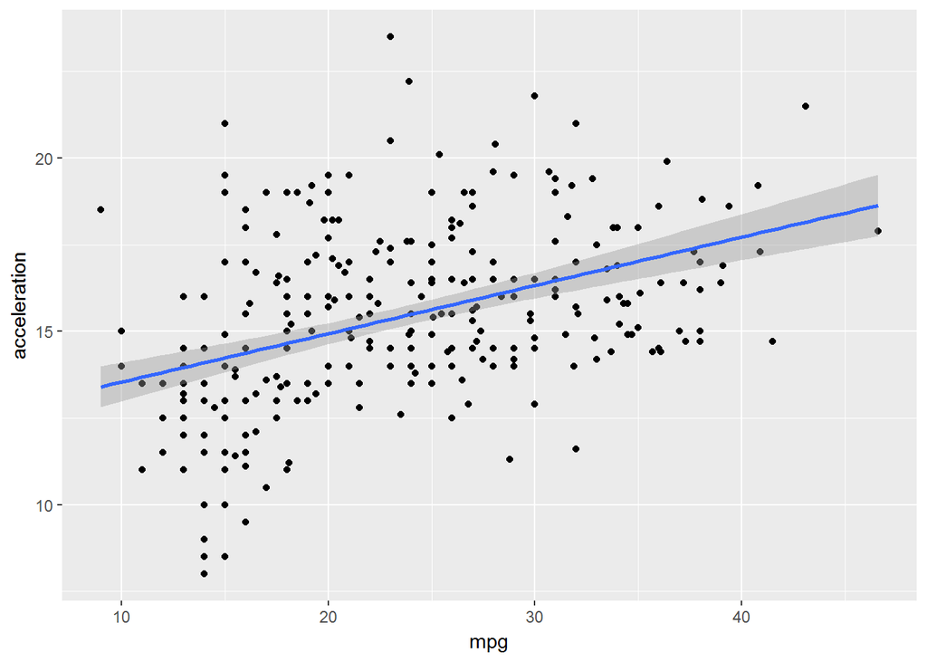

```r
ggplot(train,aes(mpg,acceleration))+geom_point()+stat_smooth(method = "lm")
```

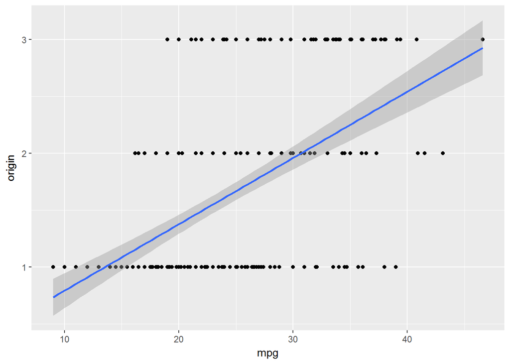

```r
ggplot(train,aes(mpg,origin))+geom_point()+stat_smooth(method = "lm")
```

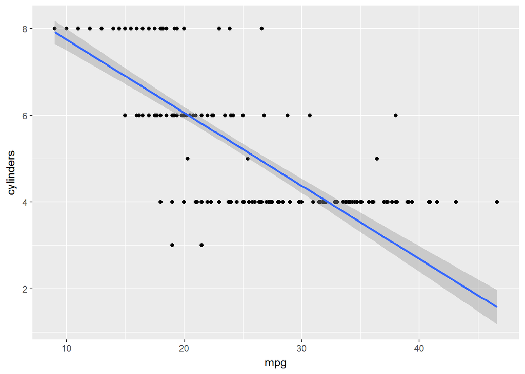

```r
ggplot(train,aes(mpg,cylinders))+geom_point()+stat_smooth(method = "lm")
```

Strong relationships between response variable can be seen in the plots.I can see also some outlier points!!Lets look at correlation matrix of all features in model:

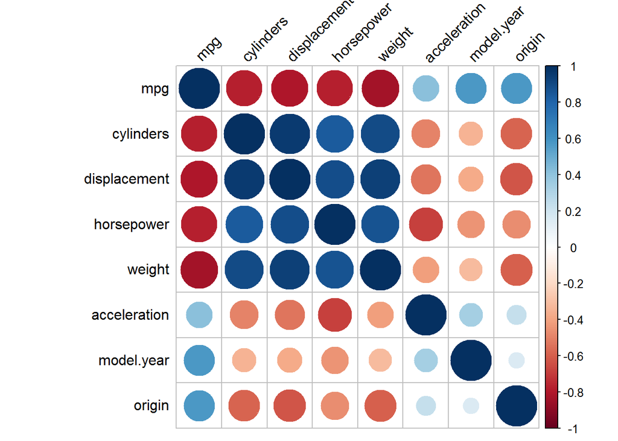

```r
require(corrplot)
corr=cor(train)
corrplot(corr, type = "full", order = "original",
         tl.col = "black", tl.srt = 45)
```

In the table above correlations coefficients between the possible pairs of variables are shown.There are highly correlated features in data. What it means for me that It has multicollinearity which violates one of Gaussian assumptions in ordinary linear regression. In order to avoid this issue, we can have other options such as principle component regression, ridge, lasso or elastic net regression model!

# 1. FULL MODEL WITH LEAST SQUARE ESTIMATION

I start with full model:

```r
lmod=lm(mpg~.,train)
summary(lmod)
```

```
##
## Call:
## lm(formula = mpg ~ ., data = train)
##
## Residuals:
##     Min      1Q  Median      3Q     Max
## -8.7759 -1.9907  0.0576  1.8892 13.0086
##
## Coefficients:
##                Estimate Std. Error t value Pr(>|t|)
## (Intercept)  -1.688e+01  5.485e+00  -3.077   0.0023 **
## cylinders    -5.444e-01  3.849e-01  -1.414   0.1585
## displacement  2.110e-02  8.839e-03   2.387   0.0177 *
## horsepower   -2.488e-04  1.524e-02  -0.016   0.9870
## weight       -7.176e-03  7.963e-04  -9.012  < 2e-16 ***
## acceleration  1.046e-01  1.222e-01   0.856   0.3928
## model.year    7.451e-01  6.051e-02  12.314  < 2e-16 ***
## origin        1.501e+00  3.329e-01   4.510 9.68e-06 ***
## ---
## Signif. codes:  0 '***' 0.001 '**' 0.01 '*' 0.05 '.' 0.1 ' ' 1
##
## Residual standard error: 3.325 on 270 degrees of freedom
## Multiple R-squared:  0.8246, Adjusted R-squared:  0.8201
## F-statistic: 181.4 on 7 and 270 DF,  p-value: < 2.2e-16
```

*** If you displacement in model, it has positivve relation with response however it is negative,….MULTILINEARITY………

horsepower, acceleration and cylinders are seen not statistical significant. However, horsepower and cylinder have strong negative correlation with response as seen above correlation diagram. This can be result from col-linearity among predictors!

After fitting a regression model it is important to determine whether all the necessary model assumptions are valid before performing inference. If there are any violations, subsequent inferential procedures may be invalid resulting in faulty conclusions. Therefore, it is crucial to perform appropriate model diagnostics. In constructing our regression models we assumed that the response y to the explanatory variables were linear in the parameters and that the errors were independent and identically distributed (i.i.d) normal random variables with mean 0 and constant variance . Model diagnostic procedures involve both graphical methods and formal statistical tests. These procedures allow us to explore whether the assumptions of the regression model are valid and decide whether we can trust subsequent inference results Lets make other diagnostic on the model:

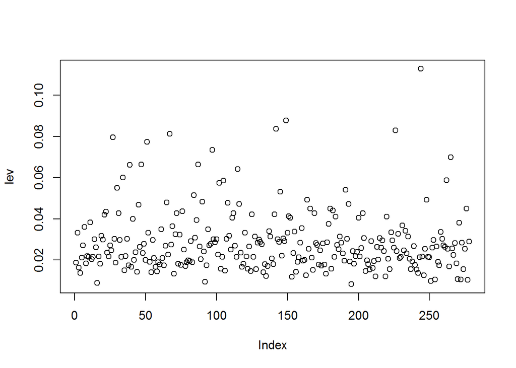

```r
lev = hat(model.matrix(lmod))
plot(lev)
```

```r
train[lev>0.10,]
```

|  | mpg | cylinders | displacement | horsepower | weight | acceleration | model.year | origin |
| --- | --- | --- | --- | --- | --- | --- | --- | --- |
| 29 | 9 | 8 | 304 | 193 | 4732 | 18.5 | 70 | 1 |

This point has highest leverage among all training set.In addition to this, i need to find influential or outlier points in model by using cook distance.

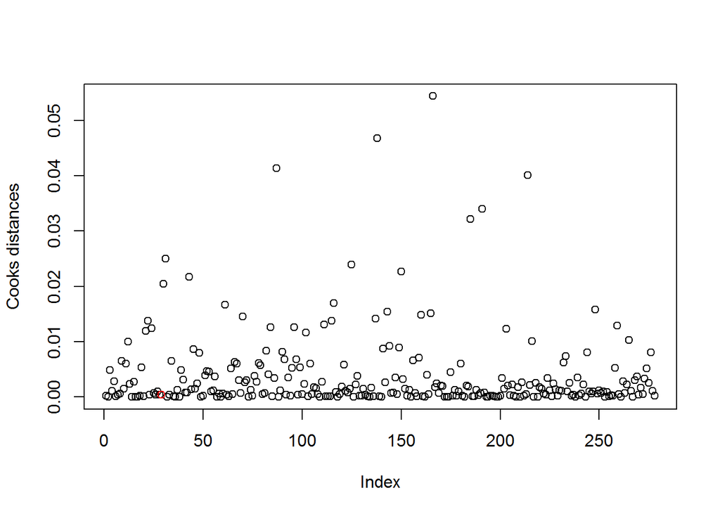

```r
cook = cooks.distance(lmod)
plot(cook,ylab="Cooks distances")
points(29,cook[29],col='red')
```

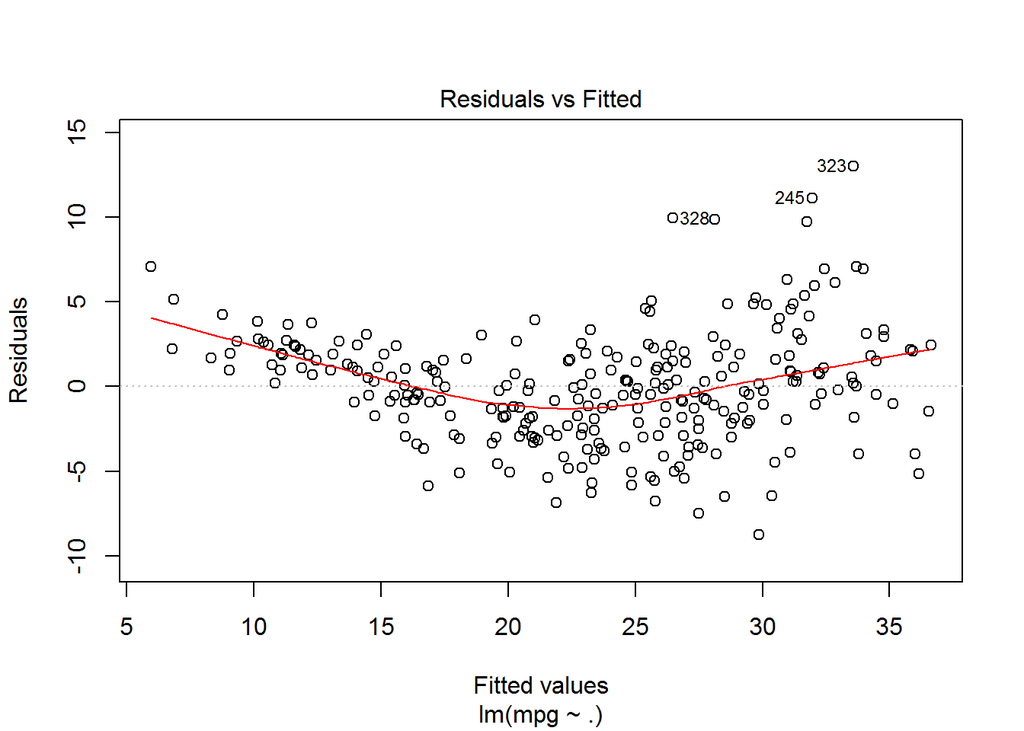

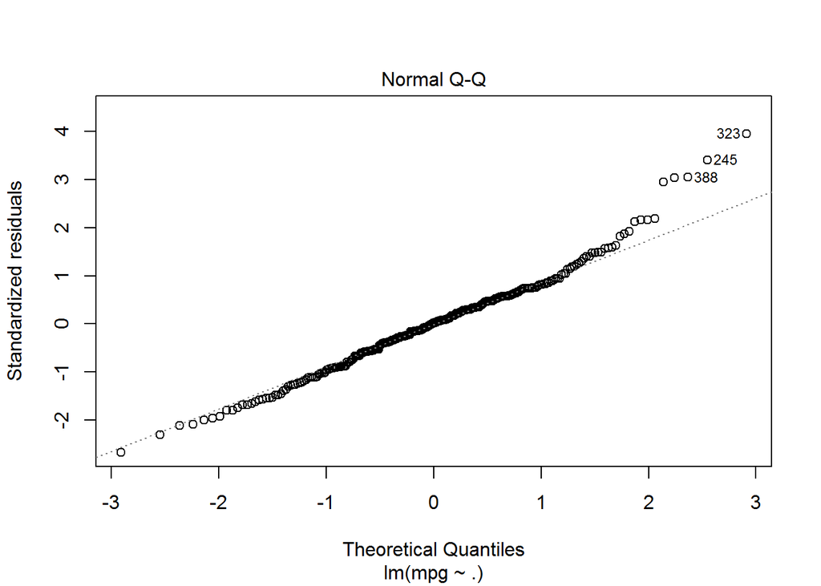

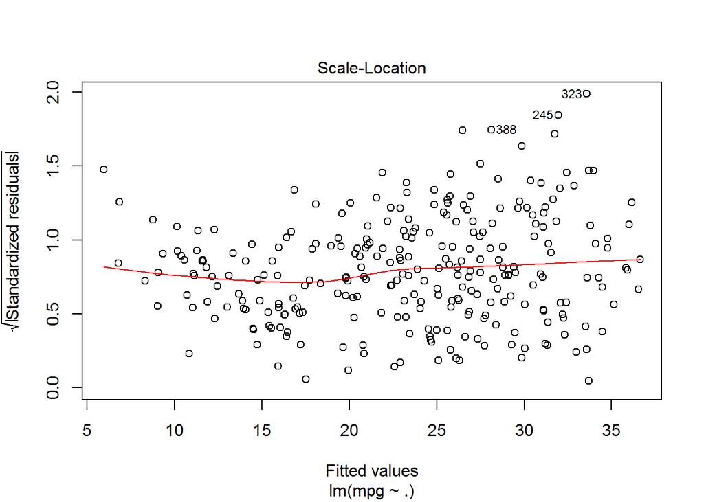

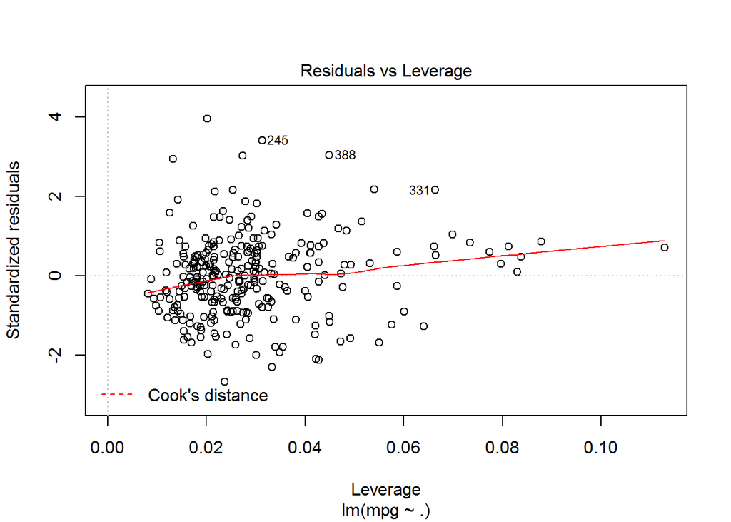

```r
plot(lmod)
```

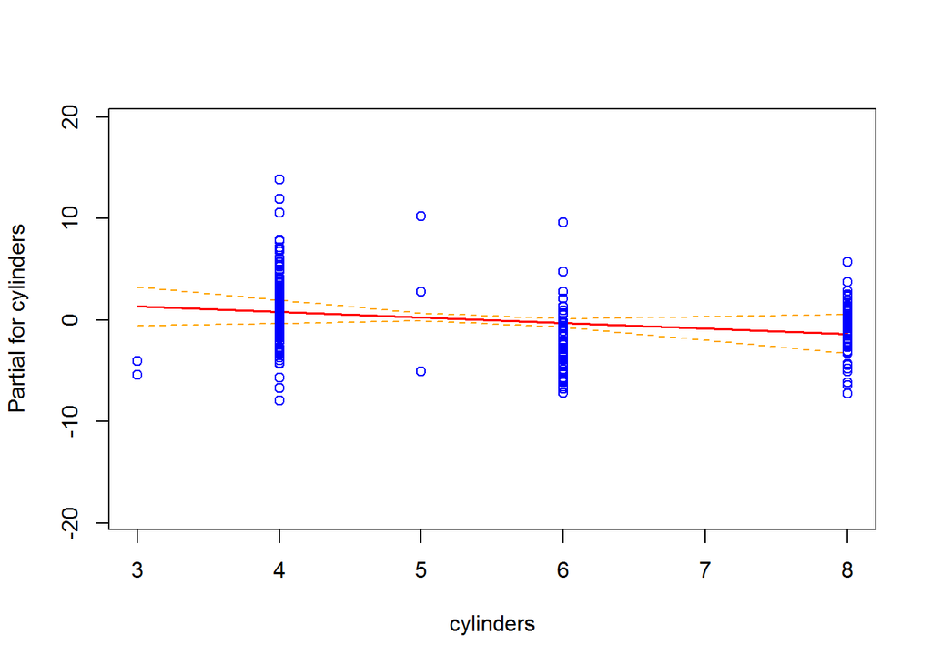

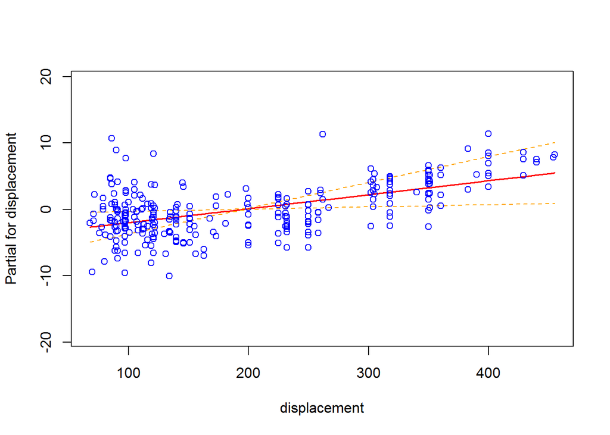

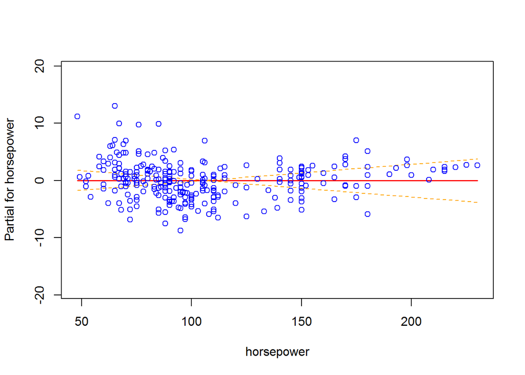

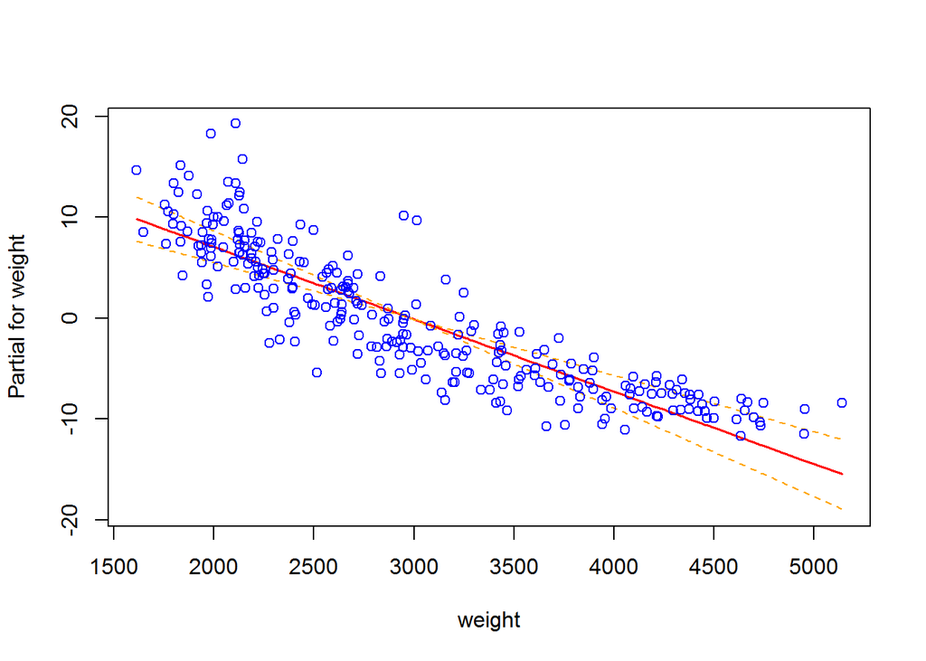

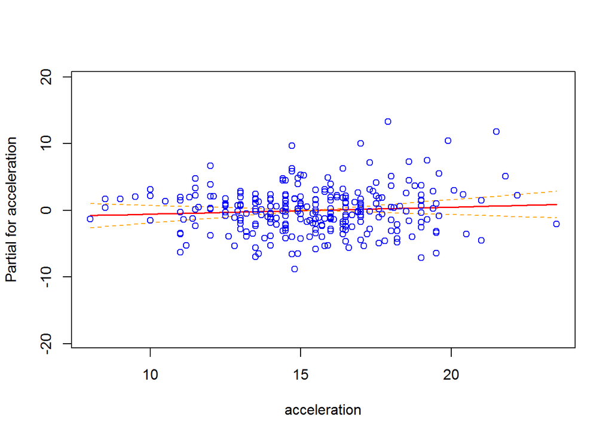

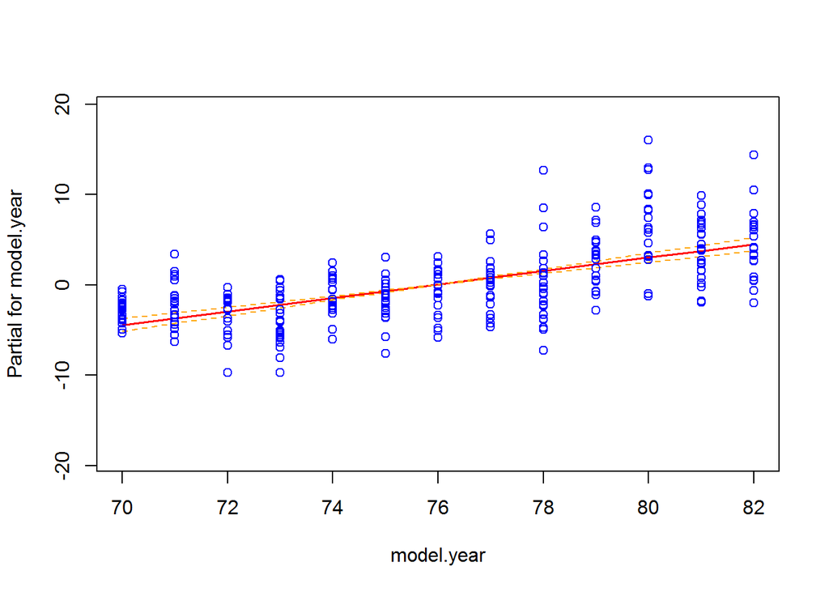

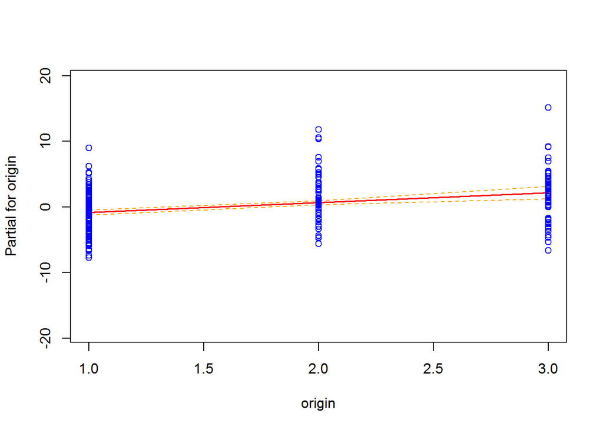

```r
termplot(lmod,partial.resid = T,se=T,col.res = "blue")
```

After looking residual plots, there is no certain way to violate one of assumptions of residual for least square estimation.Then i could not see any good transformation for all predictors.Maybe 1/sqrt might be applied to weight??? Therefore ad hoc statistical tests like t test can be regarded to eliminate features!I will also test my full model with test data by looking prediction error:

```r
missing.index=which(is.na(test$horsepower))
test$horsepower[missing.index]=mean(test$horsepower[-(missing.index)])
sqrt(mean((predict(lmod,test)-test$mpg)^2))
```

```
## [1] 3.399019
```

Even though my model is bias due to collinearity, I may tell that it produced low prediction error.

# 2. REDUCED MODEL WITH FEATURE ELIMINATION

After full model, I can discard three features that are not statistical significant , are cylinders, horsepower and acceleration.Then I make new model with transformed of weight and others:

```r
lmod1=lm(mpg~ I(1/sqrt(weight))+model.year+origin+displacement, data = train)
summary(lmod1)
```

```
##
## Call:
## lm(formula = mpg ~ I(1/sqrt(weight)) + model.year + origin +
##     displacement, data = train)
##
## Residuals:
##     Min      1Q  Median      3Q     Max
## -7.0841 -1.7739 -0.0731  1.6835 12.9130
##
## Coefficients:
##                     Estimate Std. Error t value Pr(>|t|)
## (Intercept)       -8.316e+01  6.052e+00 -13.741  < 2e-16 ***
## I(1/sqrt(weight))  2.325e+03  1.658e+02  14.024  < 2e-16 ***
## model.year         7.914e-01  5.276e-02  15.000  < 2e-16 ***
## origin             7.716e-01  2.967e-01   2.601  0.00981 **
## displacement       6.970e-03  4.322e-03   1.613  0.10797
## ---
## Signif. codes:  0 '***' 0.001 '**' 0.01 '*' 0.05 '.' 0.1 ' ' 1
##
## Residual standard error: 3.003 on 273 degrees of freedom
## Multiple R-squared:  0.8553, Adjusted R-squared:  0.8532
## F-statistic: 403.4 on 4 and 273 DF,  p-value: < 2.2e-16
```

According to summary model, displacement seems not statistical significant withe level of 0.05. In another forward elimination, I can discard this features for new model.Our transformed weight fits very well to model, this also increase the R square

```r
sqrt(mean((predict(lmod1,test)-test$mpg)^2))
```

```
## [1] 3.180154
```

R square is still high which is 0.85 and square root of prediction error is satisfactory as well.

## 3. REDUCED MODEL WITH ONE MORE ELIMINATION

```r
lmod2=lm(mpg~ I(1/sqrt(weight))+model.year+origin, data = train)
summary(lmod2)
```

```
##
## Call:
## lm(formula = mpg ~ I(1/sqrt(weight)) + model.year + origin, data = train)
##
## Residuals:
##     Min      1Q  Median      3Q     Max
## -7.0884 -1.8267 -0.0802  1.6228 13.0364
##
## Coefficients:
##                     Estimate Std. Error t value Pr(>|t|)
## (Intercept)        -75.45323    3.72214 -20.271   <2e-16 ***
## I(1/sqrt(weight)) 2101.18211   90.71900  23.161   <2e-16 ***
## model.year           0.76528    0.05036  15.197   <2e-16 ***
## origin               0.68383    0.29251   2.338   0.0201 *
## ---
## Signif. codes:  0 '***' 0.001 '**' 0.01 '*' 0.05 '.' 0.1 ' ' 1
##
## Residual standard error: 3.012 on 274 degrees of freedom
## Multiple R-squared:  0.8539, Adjusted R-squared:  0.8523
## F-statistic: 533.9 on 3 and 274 DF,  p-value: < 2.2e-16
```

R square is still high! All predictor are statistical significant! Let`s see prediction error:

```r
sqrt(mean((predict(lmod2,test)-test$mpg)^2))
```

```
## [1] 3.168299
```

This is also well level for reduced model. In backward elimination, i have discard four variable. Three of them are very higly correlated with each other.

## 4. CRITERION BASED FEATURE SELECTION

I did test based elimination above. Instead of that kind of feature selection in ordinary linear regression, I can also use AIC or BIC. I used AIC :

```r
require(leaps)
rs=summary(regsubsets(mpg~.,train))
rs$which
```

```
##   (Intercept) cylinders displacement horsepower weight acceleration
## 1        TRUE     FALSE        FALSE      FALSE   TRUE        FALSE
## 2        TRUE     FALSE        FALSE      FALSE   TRUE        FALSE
## 3        TRUE     FALSE        FALSE      FALSE   TRUE        FALSE
## 4        TRUE     FALSE         TRUE      FALSE   TRUE        FALSE
## 5        TRUE      TRUE         TRUE      FALSE   TRUE        FALSE
## 6        TRUE      TRUE         TRUE      FALSE   TRUE         TRUE
## 7        TRUE      TRUE         TRUE       TRUE   TRUE         TRUE
##   model.year origin
## 1      FALSE  FALSE
## 2       TRUE  FALSE
## 3       TRUE   TRUE
## 4       TRUE   TRUE
## 5       TRUE   TRUE
## 6       TRUE   TRUE
## 7       TRUE   TRUE
```

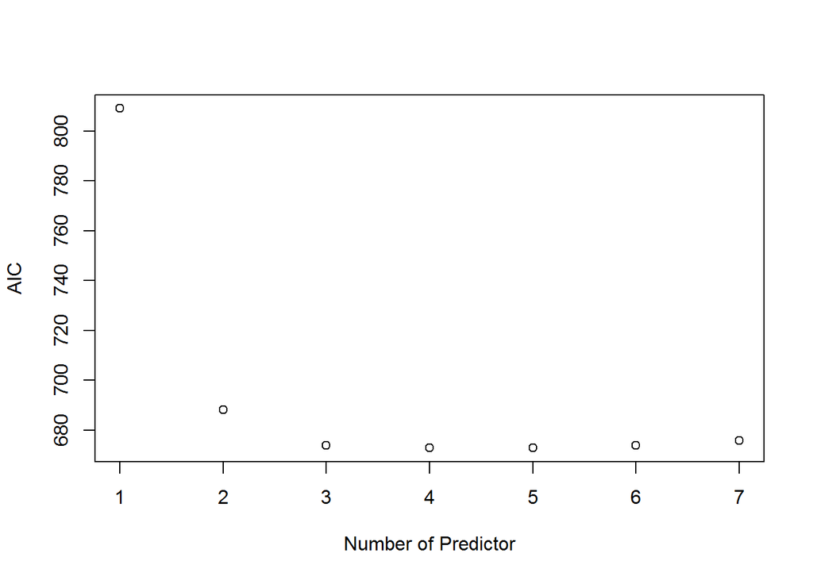

```r
n=length(train$mpg)
AIC= n*log(rs$rss/n)+(2:8)*2
plot(AIC~I(1:7),xlab="Number of Predictor")
```

in AIC process, it takes me to same way like I did in bakcward elimination. Three or four variable might be redundant features just by one step!!

## 5. SHRINKAGE METHODS/PRINCIPAL COMPONENTS ANALYSIS

PCA is a popular analysis to get lower dimensional predictor sets from higher level one.It enables us to have mutually orthogonal linear structure, which can be used to overcome collinearity problem among features.I think it is appropiate choice for our data sets , having dependent variables.lets try it on my sets:

```r
prtrain=prcomp(train)
prtrain$rotation
```

```
##                        PC1          PC2          PC3          PC4
## mpg          -0.0076723891  0.014034858 -0.036230982 -0.830260239
## cylinders     0.0017801987 -0.013485346 -0.006388937  0.004005232
## displacement  0.1148630773 -0.949158285 -0.292236395 -0.007806055
## horsepower    0.0392075448 -0.286682597  0.951651616 -0.064152961
## weight        0.9925741231  0.121376044 -0.004196946 -0.003753991
## acceleration -0.0012655044  0.034001359 -0.068099063  0.009911017
## model.year   -0.0013812940  0.025158980 -0.053387745 -0.553255232
## origin       -0.0005548962  0.003405261  0.009911609 -0.016482872
##                       PC5          PC6           PC7           PC8
## mpg          -0.551937316 -0.045669102 -0.0413017351  2.594432e-02
## cylinders     0.011064975  0.005892106  0.3533125861  9.352920e-01
## displacement  0.003307528  0.012876979  0.0007454186 -1.626856e-02
## horsepower    0.020430869  0.077751216 -0.0062569164  4.199373e-03
## weight       -0.004478297 -0.003557998 -0.0002117836  3.616624e-06
## acceleration -0.092376379  0.992724911  0.0047025684 -6.952458e-03
## model.year    0.826145485  0.077541084  0.0375187690 -2.206525e-02
## origin       -0.061193073 -0.011854104  0.9338066510 -3.517644e-01
```

```r
summary(prtrain)
```

[output not shown]

```r
#lmodpcr=lm(train$mpg~prtrain$x[,1:2])
```

In looking loadings or weights of features, we can see which variables include the variability of overall size. It means for us that we can use these kind of variable in our linear regression. In this case, weight is striking predictior in terms of variability. This variable should use in model. Then in summary of pca, first components have most of variability.Lets make regression by this.

```r
lmodpcr=lm(train$mpg~prtrain$x[,1:3])
summary(lmodpcr)
```

```
##
## Call:
## lm(formula = train$mpg ~ prtrain$x[, 1:3])
##
## Residuals:
##    Min     1Q Median     3Q    Max
## -8.909 -2.843 -0.535  2.359 16.166
##
## Coefficients:
##                       Estimate Std. Error t value Pr(>|t|)
## (Intercept)         23.3633094  0.2518694  92.760   <2e-16 ***
## prtrain$x[, 1:3]PC1 -0.0076724  0.0002941 -26.084   <2e-16 ***
## prtrain$x[, 1:3]PC2  0.0140349  0.0066224   2.119   0.0350 *
## prtrain$x[, 1:3]PC3 -0.0362310  0.0146066  -2.480   0.0137 *
## ---
## Signif. codes:  0 '***' 0.001 '**' 0.01 '*' 0.05 '.' 0.1 ' ' 1
##
## Residual standard error: 4.2 on 274 degrees of freedom
## Multiple R-squared:  0.7161, Adjusted R-squared:  0.713
## F-statistic: 230.3 on 3 and 274 DF,  p-value: < 2.2e-16
```

```r
require(pls)
```

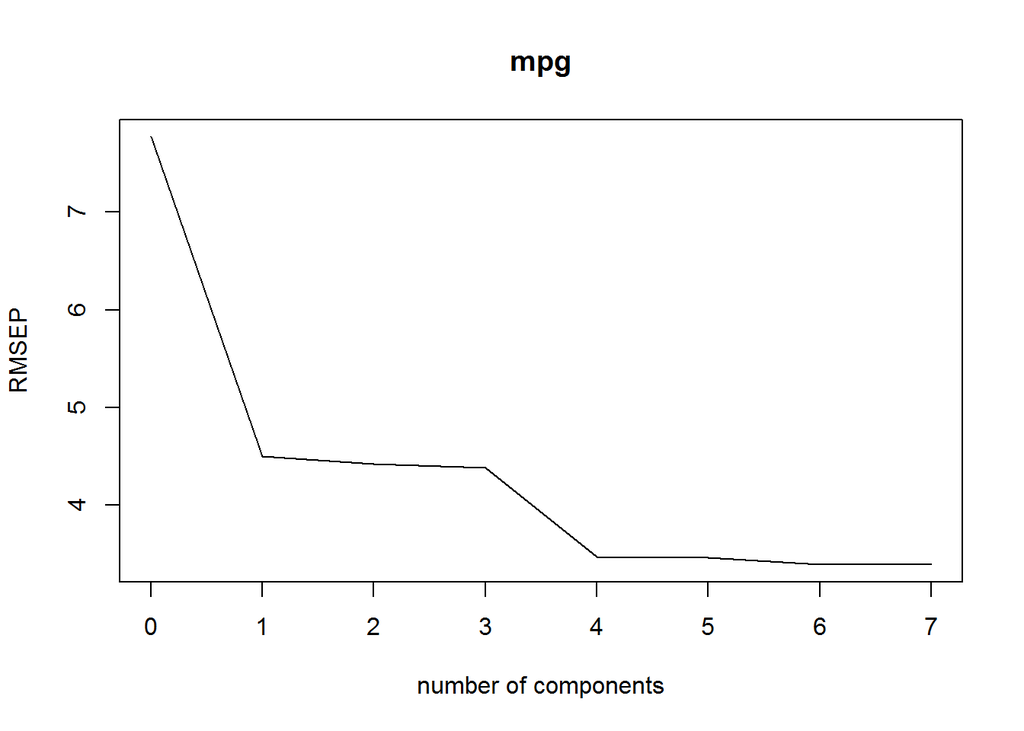

```r
pcrr=pcr(mpg ~ .,data=train, ncomp=7)
pcrrmse=RMSEP(pcrr, newdata=test)
plot(pcrrmse)
```

```r
which.min(pcrrmse$val)
```

```
## [1] 7
```

```r
y=predict(pcrr,test, ncomp = 6)
sqrt(mean((y-test$mpg)^2))
```

```
## [1] 3.394889
```

As seen above, the crossvalidated number of components is 7, by using seven pricciple components we can get prediction error like we have in ols.However, it is no reduction of dimension in model. Since, number of features is very less to use pca. It is good use in large number of predictors!!!In this porblem it is not good idea to use pca even though it has collinearity.

## PARTIAL LEAST SQUARES

PLS is method for relating input variables and response. PLS regression does not ignore response variables in determining model, although PCR takes only account relations among input variables. Therefore this is more powerful in prediction modelling.

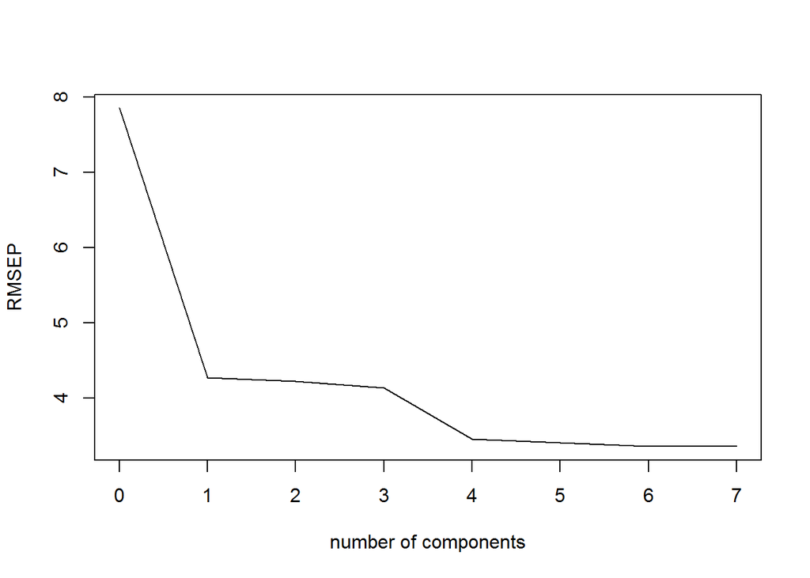

```r
plsmod= plsr(mpg ~ . , data= train, ncomp=7, validation= "CV")
PLSCV= RMSEP(plsmod, estimate="CV")
plot(PLSCV, main = "")
```

```r
y=predict(pcrr,test, ncomp = 7)
sqrt(mean((y-test$mpg)^2))
```

```
## [1] 3.399019
```

It is gives almost same results in PCA.

## RIDGE REGRESSION

```r
require(MASS)
```

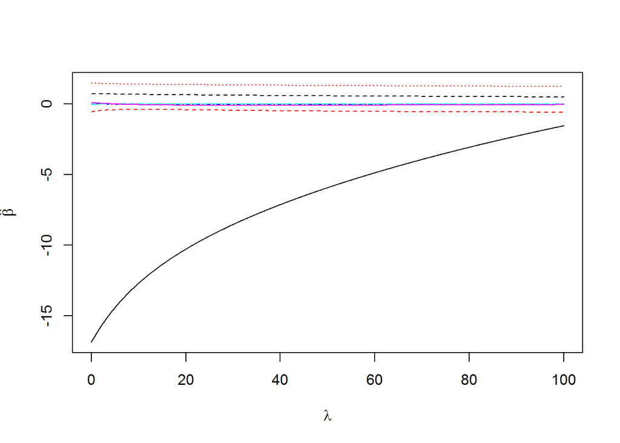

```r
ridmod=lm.ridge(mpg ~ ., train, scale = T, lambda = seq(0, 100, by=0.05))
matplot(ridmod$lambda, coef(ridmod), type="l", xlab = expression(lambda), ylab = expression(hat(beta)))
```

```r
which.min(ridmod$GCV)
```

```
##   0.85
##     18
```

```r
coef(ridmod)[18,]
```

```
##                   cylinders  displacement    horsepower        weight
## -16.384077236  -0.500815896   0.018302491  -0.002138319  -0.006880728
##  acceleration    model.year        origin
##   0.082518102   0.738537918   1.485846068
```

in ridge , after graph i can tell that model has collineraity or not you can understand change on the features that show how they affect by collinearity!!

```r
t=cbind(1,as.matrix(test))
coeff=coef(ridmod)[18,]
tdata=t[,-2]

ypred=coeff[1] * tdata[,1] + coeff[2] * tdata[,2]+  coeff[3] * tdata[,3]+ coeff[4] * tdata[,4] +
      coeff[5] * tdata[,5] + coeff[6] * tdata[,6]+  coeff[7] * tdata[,7]+ coeff[8] * tdata[,8]

a=sd(ypred)
b=mean(ypred)
res=a*ypred+b
res
```

[output not shown]

```r
#uu=ypred* sd(as.matrix(yred))+mean(yred)
sqrt(mean((ypred-t[,2])^2))
```

```
## [1] 3.390699
```

```r
#ypred=coeff %*% tdata
```